# A Bayesian framework for distributed lag non-linear models: the {bdlnm} R package

Pau  
Satorra

Germans Trias i Pujol Research Institute and Hospital (IGTP), Barcelona

**Marcos Quijal-Zamorano**

Institute of Social and Preventive Medicine (ISPM), University of Bern

**Joan Ballester**

Institut de Salut Global de Barcelona (ISGlobal)

**Miguel Ángel Martínez-Beneito**

Departament d’Estadística i Investigació Operativa, Universitat de València

**Marc Marí-Dell’Olmo**

Agència de Salut Pública de Barcelona (ASPB)

May 26, 2026

# Background

## Motivation

- Climate change is intensifying extreme environmental conditions: heatwaves, cold spells are becoming more frequent and severe
- Environmental exposures rarely act instantaneously, as their health impact unfolds over a short period of time:
  - A heatwave today may elevate mortality risk days later
  - Cold temperatures can trigger cardiovascular events time after exposure
  - Air pollution accumulates biological damage across days or weeks
- Standard regression approaches struggle to capture these **delayed** and usually **non-linear** effects simultaneously

## Distributed Lag Non-Linear Models (DLNMs)

DLNMs (Gasparrini et al. 2010) are the standard framework for capturing these short-term dynamics, simultaneously modelling two dimensions of risk:

1. **Exposure-response:** how risk changes across exposure levels

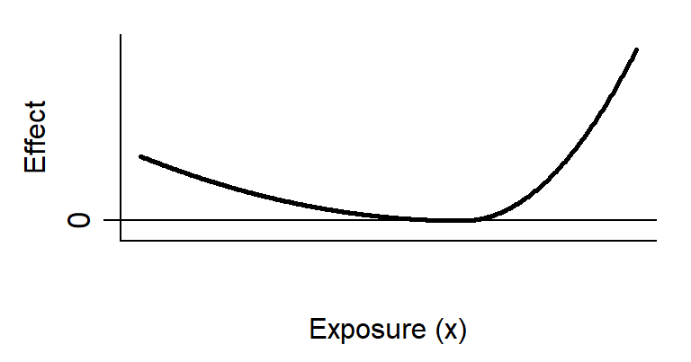

2. **Lag-response:** how risk evolves over time after exposure (lags)

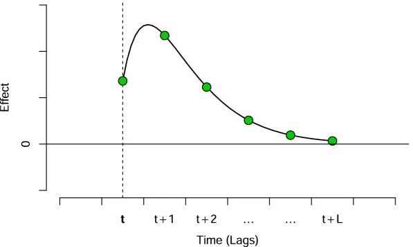

- Usually splines (natural cubic, B-splines or P-splines) are used to define these usually non-linear relationships in each dimension

## Distributed Lag Non-Linear Models (DLNMs)

- The tensor product of the two spline bases defines the **cross-basis**: a smooth bivariate surface over exposure and lag
1. **Exposure-response**

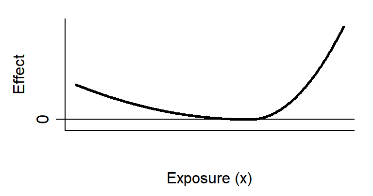

$\times$

2. **Lag-response**

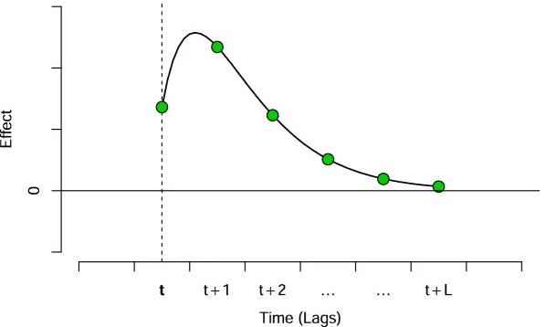

$=$

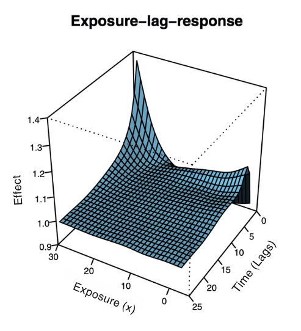

## DLNMs: Model formulation

$$\log(E(Y_t)) = \alpha + \underbrace{cb(x_t, \ldots, x_{t-L}) \cdot \boldsymbol{\beta}}_{\text{cross-basis}} + \sum_{k} \gamma_k u_{kt}$$

| Term | Description |
| --- | --- |
| $cb(\cdot)$ | **Cross-basis**: tensor product of exposure and lag spline bases |
| $\boldsymbol{\beta}$ | Coefficients of the cross-basis |
| $u_{kt}$ | (Time-varying) confounders (e.g. seasonality, trend) |
| $\gamma_k$ | Coefficients of the confounders |
| $\alpha$ | Intercept |

## Bayesian DLNMs

Same model, with **prior distributions** placed on all parameters:

$$\log(E(Y_t)) = \alpha + \underbrace{cb(x_t, \ldots, x_{t-L}) \cdot \boldsymbol{\beta}}_{\text{cross-basis}} + \sum_{k} \gamma_k u_{kt}$$

$$\alpha, \boldsymbol{\beta}, \gamma_k \sim \text{(prior distributions)}$$

Every parameter now has its **posterior distribution**

This enables:

- **Full uncertainty quantification** of all estimates via posterior distributions
- **Uncertainty propagation** in derived measures (optimal exposure, attributable burden, hypothesis testing) without additional approximations
- **Hierarchical extensions** to add layers of complexity in the model (e.g. Spatial Bayesian DLNMs, Quijal-Zamorano et al. (2024))

# The {bdlnm} R package

## {bdlnm}

[figure not shown]

- The goal of {bdlnm} is to extend frequentist DLNMs to all kinds of Bayesian DLNMs (B-DLNMs)
- Built on **{dlnm}**, the reference package for frequentist DLNMs (Gasparrini et al. 2011)
- Uses **R-INLA** (Rue et al. 2009) for efficient Bayesian inference

## Overview of the package

| Purpose | Function | Based on |
| --- | --- | --- |
| **Model fitting** | `bdlnm()` | New |
| **Optimal exposure** | `optimal_exposure()` `plot.optimal_exposure` | New |
| **Prediction** | `bcrosspred()` | `dlnm::crosspred()` |
| **Visualisation** | `plot.bcrosspred()` | `dlnm::plot.crosspred()` |
| **Attribution** | `attributable()` | `attrdl()` (Gasparrini and Leone 2014) |

# Hands-on {bdlnm}: An application

## Temperature-mortality study

- We assess the immediate and delayed non-linear effect of daily mean temperature on mortality (age 75+) in London, 2000-2011
- We will use the {bdlnm} built-in `london` dataset: one observation per day, containing mortality counts, mean temperature, and calendar variables:

| date | year | dow | tmean | mort_00_74 | mort_75plus | mort |
| --- | --- | --- | --- | --- | --- | --- |
| 2000-01-01 | 2000 | Sat | 7.642016 | 101 | 226 | 327 |
| 2000-01-02 | 2000 | Sun | 8.351041 | 100 | 191 | 291 |
| 2000-01-03 | 2000 | Mon | 8.188446 | 107 | 205 | 312 |
| 2000-01-04 | 2000 | Tue | 6.320066 | 97 | 191 | 288 |
| 2000-01-05 | 2000 | Wed | 6.550981 | 92 | 213 | 305 |
| 2000-01-06 | 2000 | Thu | 8.728774 | 82 | 213 | 295 |

(Vicedo-Cabrera et al. 2019)

## Model specification

$$Y_t \sim \text{Poisson}(\mu_t), \quad \quad \log(\mu_t) = \alpha + cb(x_t, \ldots, x_{t-L}) \cdot \beta + \sum_{k} \gamma_k u_{kt}$$

**Cross-basis** ($cb$)

- Exposure-response: natural spline, knots at **10th**, **75th**, **90th** percentiles
- Lag-response: natural spline, **3** knots on log scale, max lag **21 days**

**Confounders** ($u_{kt}$)

- Seasonality/trend: natural spline, **8 df/year**
- Day of week: factor

## Building the cross-basis

- We have to use first the {dlnm} package to build the cross-basis:

```r
library(dlnm)
argvar <- list(
  fun = "ns",
  knots = quantile(london$tmean, c(10, 75, 90) / 100, na.rm = TRUE),
  Bound = range(london$tmean, na.rm = TRUE)
)
arglag <- list(
  fun = "ns",
  knots = logknots(21, nk = 3)
)
cb <- crossbasis(london$tmean, lag = 21, argvar, arglag)
```

- And build the seasonality and temperature prediction grid:

```r
library(splines)
seas <- ns(london$date, df = round(8 * length(london$date) / 365.25))
temp <- round(seq(min(london$tmean), max(london$tmean), by = 0.1), 1)
```

## Fitting the Bayesian DLNM

```r
library(bdlnm)
mod <- bdlnm(
  mort_75plus ~ cb + factor(dow) + seas,
  data = london,
  family = "poisson",
  sample.arg = list(n = 1000, seed = 5243)
)
```

`bdlnm()` handles two things internally:

1. Fits the model using *R-INLA*
2. Returns posterior samples and summaries for all parameters

```
List of 4 (class "bdlnm")
 $ model               : list [49]      — fitted R-INLA model object
 $ basis               : list [1]       — cross-basis
 $ coefficients        : num [123, 1000] — posterior samples
 $ coefficients.summary: num [123, 6]    — posterior summary
```

## Fitting the Bayesian DLNM

Now we have a matrix with the estimated posterior samples of the model coefficients, together with their summary across samples:

**Posterior samples** `mod$coefficients`

```
                 sample1      sample2      sample3      sample4      sample5
(Intercept)  5.177126982  5.078820056  5.087683979  5.240468410  5.259946480
cbv1.l1     -0.139254820 -0.154092463 -0.112435103 -0.110085718 -0.153345807
cbv1.l2     -0.007785162  0.008057831  0.001246025 -0.003957057  0.006234502
cbv1.l3     -0.057349056 -0.056023923 -0.045405679 -0.044017955 -0.055955602
cbv1.l4      0.048904544  0.057243423  0.025429828  0.028536089  0.049960368
```

**Posterior summary** `mod$coefficients.summary`

```
                    mean         sd  0.025quant     0.5quant  0.975quant
(Intercept)  5.204972340 0.10244169  5.00329053  5.205428027  5.39781786
cbv1.l1     -0.134951449 0.02148864 -0.17689662 -0.134049849 -0.09601856
cbv1.l2     -0.006084204 0.01031606 -0.02556688 -0.006093614  0.01455691
cbv1.l3     -0.049708682 0.01141099 -0.07279473 -0.049392945 -0.02789958
cbv1.l4      0.049567985 0.01806032  0.01484373  0.050353168  0.08412770
```

* Visualizing only the first 5 coefficients and the first 5 posterior samples

## Minimum mortality temperature (MMT)

The **minimum mortality temperature (MMT)** is the temperature at which the overall cumulative mortality risk is minimised. It is used as the reference value to center relative risk estimates, so that all effects are interpreted relative to the temperature associated with lowest mortality risk

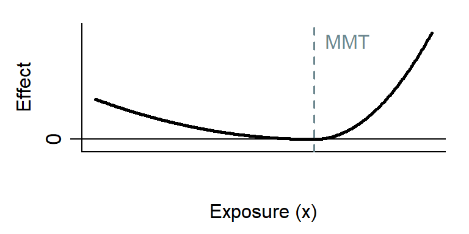

We will use the `optimal_exposure()` function to calculate it:

```r
mmt <- optimal_exposure(mod, exp_at = temp)
```

```
List of 2 (class "optimal_exposure")
 $ est    : num [1:1000] — posterior samples of the MMT
 $ summary: num [1:6]    — posterior summary (mean, sd, quantiles)
```

## MMT posterior distribution

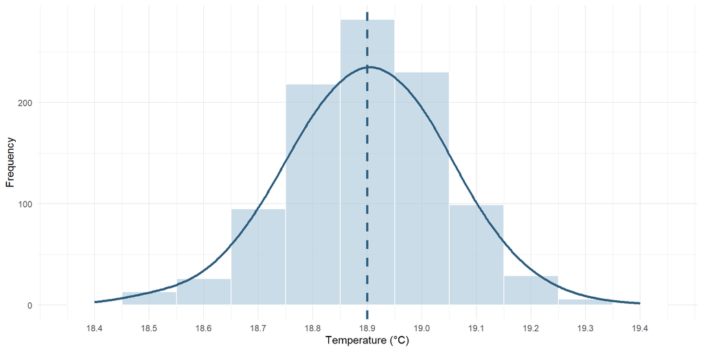

The posterior is concentrated around 18.9°C and unimodal: the median is a stable centering value for the relative risk estimates

## Predicting exposure-lag-response effects

From the fitted model, `bcrosspred()` predicts the full bivariate exposure-lag-response association. Relative risks will be centered at the MMT:

```r
cen <- mmt$summary[["0.5quant"]]
cpred <- bcrosspred(mod, exp_at = temp, cen = cen)
```

```
List (class "bcrosspred")
 $ coefficients        : num [20, 1000]      — posterior samples of cross-basis coefficients
 $ coefficients.summary: num [20, 6]         — posterior summary of cross-basis coefficients
 $ matRRfit            : num [326, 22, 1000] — posterior samples of RR (exposure x lag x samples)
 $ matRRfit.summary    : num [326, 22, 6]    — posterior summary of RR (exposure x lag x summaries)
 $ allRRfit            : num [326, 1000]     — posterior samples of overall RR (exposure x samples)
 $ allRRfit.summary    : num [326, 6]        — posterior summary of overall RR (exposure x summaries)
```

## Predicting exposure-lag-response effects

Now we have an array of estimated posterior RRs for each temperature–lag combination, together with their summary across samples:

**Posterior samples** `cpred$matRRfit`

```
, , sample1

          lag0     lag1     lag2     lag3
-3.4 0.8489699 1.078465 1.144323 1.100592
-3.3 0.8496304 1.077665 1.143102 1.099767
-3.2 0.8502913 1.076867 1.141883 1.098942
-3.1 0.8509526 1.076069 1.140665 1.098119
```

*Visualizing only first 4 temperatures and lags and 1 sample

**Posterior summary** `cpred$matRRfit.summary`

```
, , 0.5quant

          lag0     lag1     lag2     lag3
-3.4 0.8530144 1.071380 1.134944 1.094426
-3.3 0.8537183 1.070822 1.133919 1.093778
-3.2 0.8544289 1.070291 1.132961 1.093147
-3.1 0.8550786 1.069738 1.131952 1.092492
```

*Visualizing only first 4 temperatures and lags and 1 summary statistic

## `plot.bcrosspred()`: visualise predictions

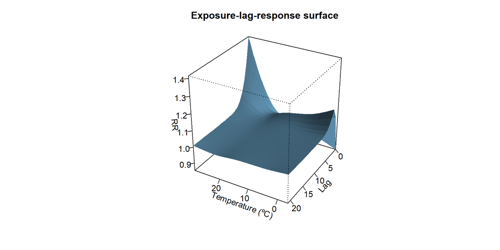

```r
plot(cpred, ptype = "3d")
```

## `plot.bcrosspred()`: visualise predictions

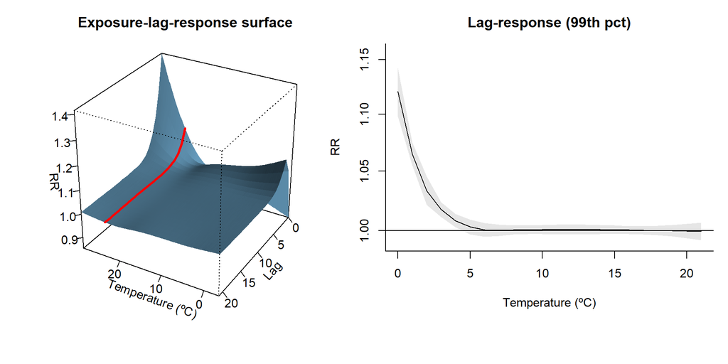

```r
plot(cpred, ptype = "3d")
plot(cpred, ptype = "slices", exp_at = round(quantile(london$tmean, 0.99), 1))
```

## `plot.bcrosspred()`: visualise predictions

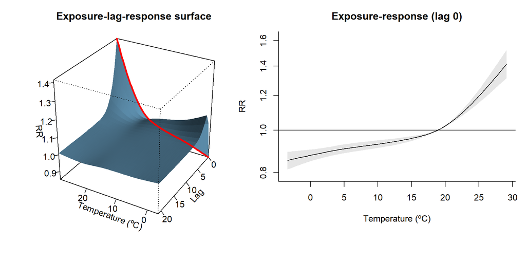

```r
plot(cpred, ptype = "3d")
plot(cpred, ptype = "slices", lag_at = 0)
```

## `plot.bcrosspred()`: visualise predictions

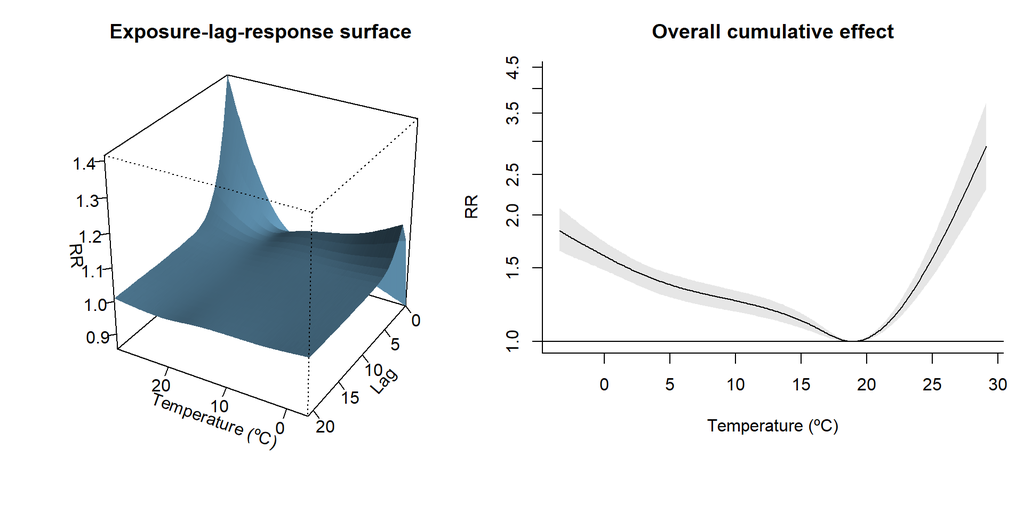

```r
plot(cpred, ptype = "3d")
plot(cpred, ptype = "overall")
```

## Attributable burden

$$\text{AF}_{x,t} = 1 - \exp(-\beta_x) \qquad \text{AN}_{x,t} = n_t \cdot \text{AF}_{x,t}$$

- In a DLNM setting, the overall cumulative effect $\beta_{x,\,\text{overall}}$ can be used as $\beta_x$ (forward perspective)

It’s important to center effects to the optimal temperature if we want to calculate the attribution to non-optimal temperatures

## Computing attributable burden

`attributable()` returns daily and aggregated AF and AN:

```r
attr <- attributable(mod, london, name_date = "date", name_exposure = "tmean", name_cases = "mort_75plus", cen = cen, dir = "forw")
```

```
List of 8
 $ af             : num [4383, 1000] — posterior samples of daily AF
 $ an             : num [4383, 1000] — posterior samples of daily AN
 $ aftotal        : num [1:1000]     — posterior samples of total AF
 $ antotal        : num [1:1000]     — posterior samples of total AN
 $ af.summary     : num [4383, 6]    — posterior summary of daily AF
 $ an.summary     : num [4383, 6]    — posterior summary of daily AN
 $ aftotal.summary: num [1:6]        — posterior summary of total AF
 $ antotal.summary: num [1:6]        — posterior summary of total AN
```

## Daily attributable fraction

Time series of daily attributable fractions (AF), together with the temperature exposition in that given day:

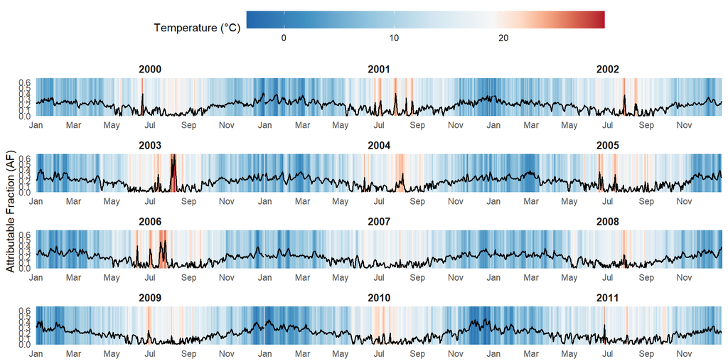

## Total attributable burden

Total mortality burden attributable to non-optimal temperatures in the London 75+ population across 2000–2011:

|  | 0.5quant | 0.025quant | 0.975quant |
| --- | --- | --- | --- |
| Total Attributable Fraction | 17.46% | 13.9% | 20.7% |
| Total Attributable Number | 69,200 | 55,093 | 82,016 |

Be cautious about the interpretation of these results as we estimate an association from an observational study, and not a causal effect

# Conclusions

## Conclusions

- The {bdlnm} package provides a complete and accessible implementation of Bayesian Distributed Lag Non-Linear Models in R
- Combining the flexibility of DLNMs with full Bayesian inference enables researchers to fit more realistic and complex models
- The posterior distribution of all estimates allows direct uncertainty quantification of derived measures (e.g., MMT, attributable fractions, attributable numbers) without additional approximations
- Posterior summaries are fully compatible with frequentist workflows, making adoption straightforward for practitioners familiar with {dlnm}
- {bdlnm} constitutes a valuable tool for environmental risk research and, more generally, for any time series analysis with delayed effects

## Present and future work

**Coming soon:**

- **Multi-location analysis:** model different exposure-lag-response associations across cities or regions within a single model (e.g., SB-DLNM)
- **Parallelization:** faster inference via {futurize} for large datasets
- **Compatibility beyond INLA:** use MCMC algorithms (e.g. NIMBLE, Stan) for Bayesian inference

## Further resources

[figure not shown]

📦 **Full tutorials** and documentation are available on the package website  
pasahe.github.io/bdlnm

[figure not shown]

🐛 **Bug reports and contributions** are welcome via the GitHub repository  
github.com/pasahe/bdlnm

## References

Gasparrini, A., B. Armstrong, and M. G. Kenward. 2010. “Distributed Lag Non-Linear Models.” *Statistics in Medicine* 29 (21): 2224–34. https://doi.org/https://doi.org/10.1002/sim.3940.

Gasparrini, Antonio, Ben Armstrong, and Fabian Scheipl. 2011. “Distributed Lag Linear and Non-Linear Models in R: The Package dlnm.” *Journal of Statistical Software* 43 (8): 1–20. https://doi.org/10.18637/jss.v043.i08.

Gasparrini, Antonio, and Michela Leone. 2014. “Attributable Risk from Distributed Lag Models.” *BMC Medical Research Methodology* 14 (April): 55. https://doi.org/10.1186/1471-2288-14-55.

Quijal-Zamorano, Marcos, Miguel A Martinez-Beneito, Joan Ballester, and Marc Marí-Dell’Olmo. 2024. “Spatial Bayesian Distributed Lag Non-Linear Models (SB-DLNM) for Small-Area Exposure-Lag-Response Epidemiological Modelling.” *International Journal of Epidemiology* 53 (3): dyae061. https://doi.org/10.1093/ije/dyae061.

Rue, Håvard, Sara Martino, and Nicholas Chopin. 2009. “Approximate Bayesian Inference for Latent Gaussian Models Using Integrated Nested Laplace Approximations (with Discussion).” *Journal of the Royal Statistical Society B* 71: 319–92.

Vicedo-Cabrera, Ana M., Francesco Sera, and Antonio Gasparrini. 2019. “A Hands-on Tutorial on a Modeling Framework for Projections of Climate Change Impacts on Health.” *Epidemiology* 30 (3): 321–29. https://doi.org/10.1097/ede.0000000000000982.

# Thank you!

[figure not shown]

[pasahe.github.io/bdlnm](https://pasahe.github.io/bdlnm/)

# Appendix

## Spatial Bayesian DLNMs (SB-DLNMs)

SB-DLNMs (Quijal-Zamorano et al. 2024) adds a **spatial structure** to the cross-basis coefficients for reliable **small-area estimation**:

$$Y_{it} \sim \text{Poisson}(\mu_{it}) \qquad \log(\mu_{it}) = \alpha_i + \underbrace{cb(x_{it}, \ldots, x_{it-L}) \cdot \beta_i}_{\text{spatial cross-basis}} + \sum_{k} \gamma_k u_{kit}$$

$$\beta_i = \mu_\beta + \phi_i + \epsilon_i, \qquad \phi_i \mid \phi_{-i} \sim \mathcal{N}\!\left(\bar{\phi}_{\delta_i},\, \frac{\sigma^2_\phi}{|\delta_i|}\right)$$

| Term | Description |
| --- | --- |
| $\beta_i$ | Location-specific cross-basis coefficients |
| $\mu_\beta$ | Overall pooled exposure-lag-response association |
| $\phi_i$ | Spatially structured random effect (ICAR prior) |
| $\epsilon_i \sim \mathcal{N}(0, \sigma^2_\epsilon)$ | Unstructured random effect |
| $\delta_i$ | Set of spatial neighbours of area $i$ |

## Exposure-lag-response surface

The full bivariate association can be represented as a 3-D surface over temperature and lag, giving the RR at each specific temperature-lag combination:

[interactive chart not shown]

## Overall cumulative effect

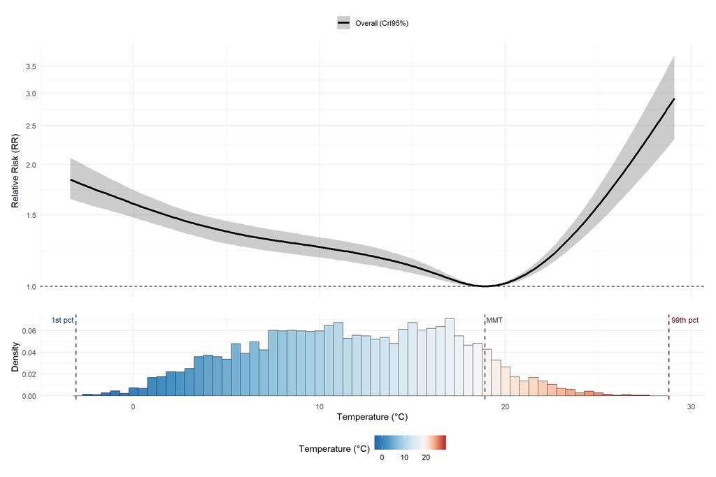